# Project - Data Mining

### Understanding the data:

```python
#Checking the shape of the data

print('The number of rows:', ins_df.shape[0] )
print('\nThe number of columns:', ins_df.shape[1])
```

```
The number of rows: 3000

The number of columns: 10
```

```python
#Describing the dataset and looking at the five number summary

ins_df.describe().T
```

|  | count | mean | std | min | 25% | 50% | 75% | max |
| --- | --- | --- | --- | --- | --- | --- | --- | --- |
| Age | 3000.0 | 38.091000 | 10.463518 | 8.0 | 32.0 | 36.00 | 42.000 | 84.00 |
| Commision | 3000.0 | 14.529203 | 25.481455 | 0.0 | 0.0 | 4.63 | 17.235 | 210.21 |
| Duration | 3000.0 | 70.001333 | 134.053313 | -1.0 | 11.0 | 26.50 | 63.000 | 4580.00 |
| Sales | 3000.0 | 60.249913 | 70.733954 | 0.0 | 20.0 | 33.00 | 69.000 | 539.00 |

From the above summary of the dataset, we can observe few details about the data like,

1. Maximum age of the insured is 84 years and minimum age is 8 years.
2. Mean age is around 38.
3. One odd thing we can observe here is that the minimum duration of the tour is -1., but duration can't be negative, so this means it is an outlier, and also maximum duration is 4580, that can also be an outlier in our dataset, that we will treat later.
4. Maximum commision taken by agency is 210.21 and the minimum is 0.

```python
#Checking the info about the data

ins_df.info()
```

```
<class 'pandas.core.frame.DataFrame'>
RangeIndex: 3000 entries, 0 to 2999
Data columns (total 10 columns):
 #   Column        Non-Null Count  Dtype
---  ------        --------------  -----
 0   Age           3000 non-null   int64
 1   Agency_Code   3000 non-null   object
 2   Type          3000 non-null   object
 3   Claimed       3000 non-null   object
 4   Commision     3000 non-null   float64
 5   Channel       3000 non-null   object
 6   Duration      3000 non-null   int64
 7   Sales         3000 non-null   float64
 8   Product Name  3000 non-null   object
 9   Destination   3000 non-null   object
dtypes: float64(2), int64(2), object(6)
memory usage: 234.5+ KB
```

In the dataset, we can see from the info that there are 2 variables with float datatype, 2 with integer datatype, 6 with object or string datatype. There are no null values present.

```python
#Checking the null/missing values if any

ins_df.isnull().sum()
```

```
Age             0
Agency_Code     0
Type            0
Claimed         0
Commision       0
Channel         0
Duration        0
Sales           0
Product Name    0
Destination     0
dtype: int64
```

```python
# We need to check for duplicates if any

duplicate_records = ins_df.duplicated()

print('Number of duplicate rows = %d' % (duplicate_records.sum()))

ins_df[duplicate_records]
```

```
Number of duplicate rows = 139
```

|  | Age | Agency_Code | Type | Claimed | Commision | Channel | Duration | Sales | Product Name | Destination |
| --- | --- | --- | --- | --- | --- | --- | --- | --- | --- | --- |
| 63 | 30 | C2B | Airlines | Yes | 15.0 | Online | 27 | 60.0 | Bronze Plan | ASIA |
| 329 | 36 | EPX | Travel Agency | No | 0.0 | Online | 5 | 20.0 | Customised Plan | ASIA |
| 407 | 36 | EPX | Travel Agency | No | 0.0 | Online | 11 | 19.0 | Cancellation Plan | ASIA |
| 411 | 35 | EPX | Travel Agency | No | 0.0 | Online | 2 | 20.0 | Customised Plan | ASIA |
| 422 | 36 | EPX | Travel Agency | No | 0.0 | Online | 5 | 20.0 | Customised Plan | ASIA |
| ... | ... | ... | ... | ... | ... | ... | ... | ... | ... | ... |
| 2940 | 36 | EPX | Travel Agency | No | 0.0 | Online | 8 | 10.0 | Cancellation Plan | ASIA |
| 2947 | 36 | EPX | Travel Agency | No | 0.0 | Online | 10 | 28.0 | Customised Plan | ASIA |
| 2952 | 36 | EPX | Travel Agency | No | 0.0 | Online | 2 | 10.0 | Cancellation Plan | ASIA |
| 2962 | 36 | EPX | Travel Agency | No | 0.0 | Online | 4 | 20.0 | Customised Plan | ASIA |
| 2984 | 36 | EPX | Travel Agency | No | 0.0 | Online | 1 | 20.0 | Customised Plan | ASIA |

139 rows × 10 columns

As we can see there are 139 duplicate records are present in the dataset.

So we are not removing the duplicates from our dataset.

### Few Countplot for measure counts

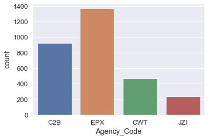

```python
 sns.countplot(data = ins_df, x = 'Agency_Code')
```

EPX (Agency_Code) has highest number of customers, and JZI has the lowest number of customers.

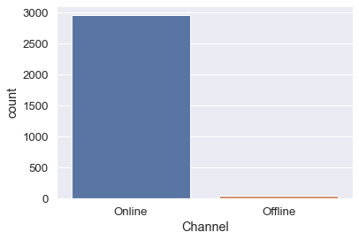

```python
#Countplot for 'Channel'
sns.countplot(data = ins_df, x = 'Channel')
```

We can see that the majority of the customers used 'Online' Channel for the insurance services.

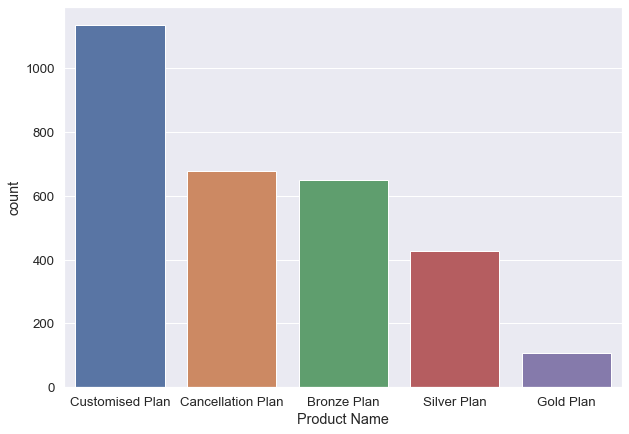

```python
#Countplot for 'Product Name':

size_of_plot = (10, 7)
fig, ax = plt.subplots(figsize=size_of_plot)
sns.countplot(ax=ax, data=ins_df, x = 'Product Name')
```

As per the above shown figure, we can observe that most of the customers want to customize their plan as per their requirement and so the customers who opt for the 'Customised Plan' are more than 1000.

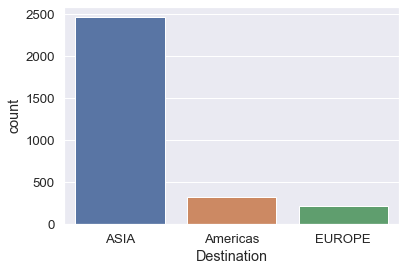

```python
#Countplot for 'Destination'

sns.countplot(data = ins_df, x = 'Destination')
```

Majority of the customers choose 'ASIA' as their preferred Destination.

### Performing Crosstab validations just to get the claimed count with respect to few variables

```python
#Crosstab validation between 'Type' and 'Claimed'

print('Count of different type of tour insurance firms:\n',ins_df.Type.value_counts())

crosstab_1 = pd.crosstab(ins_df['Type'], ins_df['Claimed'], margins = False)

crosstab_1
```

```
Count of different type of tour insurance firms:
 Travel Agency    1837
Airlines         1163
Name: Type, dtype: int64
```

| Claimed Type | No | Yes |
| --- | --- | --- |
| Airlines | 573 | 590 |
| Travel Agency | 1503 | 334 |

In Airlines tour insurance firm, out of total 1163 people, 590 people has claimed and 573 did not claimed their insurance.

In Travel Agency, out of total 1837 people, only 334 people has taken the claim and 1503 did not go for it.

```python
#Crosstab validation between 'Channel' and 'Claimed'


print('Count of different Distribution channel of tour insurance agencies:\n',ins_df.Channel.value_counts())

crosstab_2 = pd.crosstab(ins_df['Channel'], ins_df['Claimed'], margins = False)

crosstab_2
```

```
Count of different Distribution channel of tour insurance agencies:
 Online     2954
Offline      46
Name: Channel, dtype: int64
```

| Claimed Channel | No | Yes |
| --- | --- | --- |
| Offline | 29 | 17 |
| Online | 2047 | 907 |

Through online channel, out of total 2954 members, only 907 claimed their insurance and 2047 did not go for it.

Through offline channel, out of total 46, only 17 claimed and 29 did not claimed.

### Checking for Outliers for Continuous variables using Boxplot

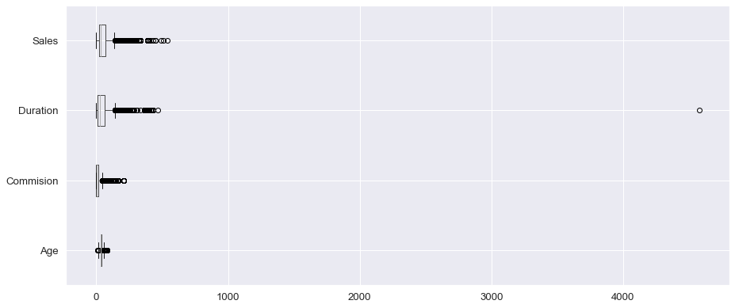

```python
plt.figure(figsize=(15,6.5))

ins_df[['Age','Commision', 'Duration', 'Sales']].boxplot(vert=0)
```

As we can see that there are outliers present in all 4 features of our data.

### Displaying Pairplot to see pair wise distribution of continuous variables:

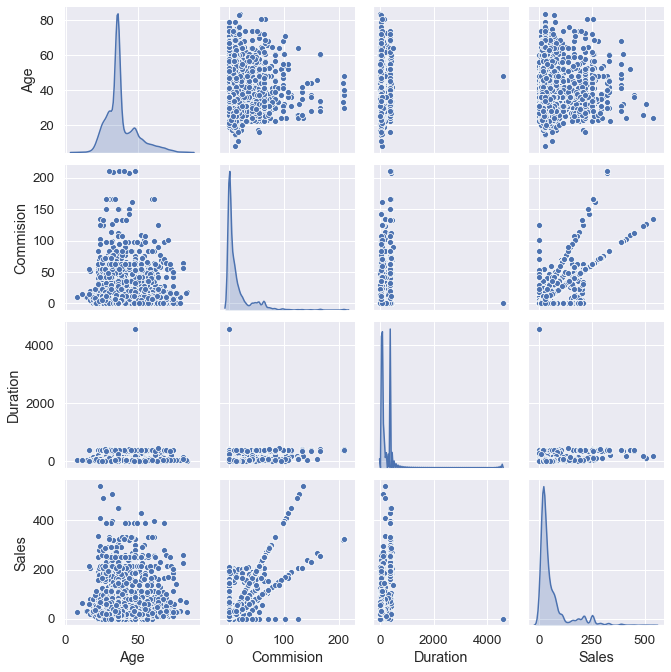

```python
sns.pairplot(ins_df[['Age', 'Commision', 'Duration', 'Sales']], height=2.3, diag_kind="kde")
```

### Displaying Correlations with heatmap for only continuous variables

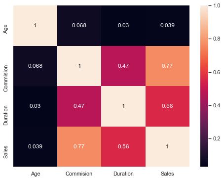

```python
#Displaying Correlations with heatmap for only continuous variables

plt.figure(figsize=(8,6))
sns.set(font_scale=1)
sns.heatmap(ins_df[['Age', 'Commision', 'Duration', 'Sales']].corr(), annot=True)
```

### 2.2 Data Split: Split the data into test and train, build classification model CART, Random Forest, Artificial Neural Network

```python
# Decision tree in Python can take only numerical(categorical) columns. It cannot take string(object) datatypes.

# So, we are converting object datatypes into categorical with each distinct value becoming a category or code.

for feature in ins_df.columns:
    if ins_df[feature].dtype == 'object':
        print('\n')
        print('feature:',feature)
        print('Unique Categories:\n', pd.Categorical(ins_df[feature].unique()))
        print(pd.Categorical(ins_df[feature].unique()).codes)
        ins_df[feature] = pd.Categorical(ins_df[feature]).codes
```

```
feature: Agency_Code
Unique Categories:
 [C2B, EPX, CWT, JZI]
Categories (4, object): [C2B, CWT, EPX, JZI]
[0 2 1 3]


feature: Type
Unique Categories:
 [Airlines, Travel Agency]
Categories (2, object): [Airlines, Travel Agency]
[0 1]


feature: Claimed
Unique Categories:
 [No, Yes]
Categories (2, object): [No, Yes]
[0 1]


feature: Channel
Unique Categories:
 [Online, Offline]
Categories (2, object): [Offline, Online]
[1 0]


feature: Product Name
Unique Categories:
 [Customised Plan, Cancellation Plan, Bronze Plan, Silver Plan, Gold Plan]
Categories (5, object): [Bronze Plan, Cancellation Plan, Customised Plan, Gold Plan, Silver Plan]
[2 1 0 4 3]


feature: Destination
Unique Categories:
 [ASIA, Americas, EUROPE]
Categories (3, object): [ASIA, Americas, EUROPE]
[0 1 2]
```

```python
#After changing object datatypes into categorical, checking the info again

ins_df.info()
```

```
<class 'pandas.core.frame.DataFrame'>
RangeIndex: 3000 entries, 0 to 2999
Data columns (total 10 columns):
 #   Column        Non-Null Count  Dtype
---  ------        --------------  -----
 0   Age           3000 non-null   int64
 1   Agency_Code   3000 non-null   int8
 2   Type          3000 non-null   int8
 3   Claimed       3000 non-null   int8
 4   Commision     3000 non-null   float64
 5   Channel       3000 non-null   int8
 6   Duration      3000 non-null   int64
 7   Sales         3000 non-null   float64
 8   Product Name  3000 non-null   int8
 9   Destination   3000 non-null   int8
dtypes: float64(2), int64(2), int8(6)
memory usage: 111.5 KB
```

We can see that all the object data types variables are now changed into categorical values.

```python
#Checking the head again

ins_df.head()
```

|  | Age | Agency_Code | Type | Claimed | Commision | Channel | Duration | Sales | Product Name | Destination |
| --- | --- | --- | --- | --- | --- | --- | --- | --- | --- | --- |
| 0 | 48 | 0 | 0 | 0 | 0.70 | 1 | 7 | 2.51 | 2 | 0 |
| 1 | 36 | 2 | 1 | 0 | 0.00 | 1 | 34 | 20.00 | 2 | 0 |
| 2 | 39 | 1 | 1 | 0 | 5.94 | 1 | 3 | 9.90 | 2 | 1 |
| 3 | 36 | 2 | 1 | 0 | 0.00 | 1 | 4 | 26.00 | 1 | 0 |
| 4 | 33 | 3 | 0 | 0 | 6.30 | 1 | 53 | 18.00 | 0 | 0 |

```python
#Checking the Proportion of 1s and 0s:

print(ins_df.Type.value_counts(normalize=True))
print('\n--------------------------------------------\n')
print(ins_df.Claimed.value_counts(normalize=True))
print('\n--------------------------------------------\n')
print(ins_df.Channel.value_counts(normalize=True))
print('\n--------------------------------------------\n')
print(ins_df.Agency_Code.value_counts(normalize=True))
print('\n--------------------------------------------\n')
print(ins_df.Destination.value_counts(normalize=True))
```

```
1    0.612333
0    0.387667
Name: Type, dtype: float64

--------------------------------------------

0    0.692
1    0.308
Name: Claimed, dtype: float64

--------------------------------------------

1    0.984667
0    0.015333
Name: Channel, dtype: float64

--------------------------------------------

2    0.455000
0    0.308000
1    0.157333
3    0.079667
Name: Agency_Code, dtype: float64

--------------------------------------------

0    0.821667
1    0.106667
2    0.071667
Name: Destination, dtype: float64
```

```python
#Checking the value counts of ‘Claimed’ individuals

ins_df.Claimed.value_counts()
```

```
0    2076
1     924
Name: Claimed, dtype: int64
```

Here, 1 indicates the number of customers who claimed the insurance, and 0 indicates the number f customer who did not claimed their insurance.

### Splitting the data into training and test set

```python
#First step is to separate the dependent variable(target column/variable) and independent variable

#Target column is 'Claimed' for this data

X = ins_df.drop('Claimed', axis=1)

y = ins_df['Claimed']
```

```python
X.head()
```

|  | Age | Agency_Code | Type | Commision | Channel | Duration | Sales | Product Name | Destination |
| --- | --- | --- | --- | --- | --- | --- | --- | --- | --- |
| 0 | 48 | 0 | 0 | 0.70 | 1 | 7 | 2.51 | 2 | 0 |
| 1 | 36 | 2 | 1 | 0.00 | 1 | 34 | 20.00 | 2 | 0 |
| 2 | 39 | 1 | 1 | 5.94 | 1 | 3 | 9.90 | 2 | 1 |
| 3 | 36 | 2 | 1 | 0.00 | 1 | 4 | 26.00 | 1 | 0 |
| 4 | 33 | 3 | 0 | 6.30 | 1 | 53 | 18.00 | 0 | 0 |

```python
from sklearn.model_selection import train_test_split


# We are splitting train set and test set to 70% and 30% of the data respectively.

X_train, X_test, train_labels, test_labels = train_test_split(X, y, test_size=.30, random_state=1)
```

```python
print('X_train has 70% of the data, it has {} rows and {} columns'.format(X_train.shape[0],X_train.shape[1]))

X_train
```

```
X_train has 70% of the data, it has 2100 rows and 9 columns
```

|  | Age | Agency_Code | Type | Commision | Channel | Duration | Sales | Product Name | Destination |
| --- | --- | --- | --- | --- | --- | --- | --- | --- | --- |
| 1045 | 36 | 2 | 1 | 0.00 | 1 | 30 | 20.00 | 2 | 0 |
| 2717 | 36 | 2 | 1 | 0.00 | 1 | 139 | 42.00 | 2 | 1 |
| 2835 | 28 | 0 | 0 | 46.96 | 1 | 367 | 187.85 | 4 | 0 |
| 2913 | 28 | 0 | 0 | 12.13 | 1 | 29 | 48.50 | 4 | 0 |
| 959 | 48 | 1 | 1 | 18.62 | 1 | 53 | 49.00 | 3 | 0 |
| ... | ... | ... | ... | ... | ... | ... | ... | ... | ... |
| 2763 | 39 | 0 | 0 | 34.13 | 1 | 55 | 136.50 | 3 | 0 |
| 905 | 41 | 0 | 0 | 6.00 | 1 | 9 | 15.00 | 0 | 0 |
| 1096 | 36 | 2 | 1 | 0.00 | 1 | 131 | 63.00 | 2 | 0 |
| 235 | 44 | 3 | 0 | 6.30 | 1 | 6 | 18.00 | 0 | 0 |
| 1061 | 36 | 0 | 0 | 5.63 | 1 | 85 | 22.50 | 4 | 0 |

2100 rows × 9 columns

```python
print('X_test has 30% of the data, it has {} rows and {} columns'.format(X_test.shape[0],X_test.shape[1]))

X_test
```

```
X_test has 30% of the data, it has 900 rows and 9 columns
```

|  | Age | Agency_Code | Type | Commision | Channel | Duration | Sales | Product Name | Destination |
| --- | --- | --- | --- | --- | --- | --- | --- | --- | --- |
| 1957 | 22 | 1 | 1 | 28.50 | 1 | 28 | 75.0 | 0 | 2 |
| 2087 | 55 | 0 | 0 | 6.63 | 1 | 24 | 26.5 | 0 | 0 |
| 1394 | 29 | 0 | 0 | 4.00 | 1 | 33 | 16.0 | 0 | 0 |
| 1520 | 27 | 0 | 0 | 15.88 | 1 | 40 | 63.5 | 4 | 0 |
| 1098 | 36 | 2 | 1 | 0.00 | 1 | 35 | 27.0 | 1 | 0 |
| ... | ... | ... | ... | ... | ... | ... | ... | ... | ... |
| 2363 | 36 | 2 | 1 | 0.00 | 1 | 3 | 29.0 | 1 | 0 |
| 270 | 35 | 2 | 1 | 0.00 | 1 | 2 | 20.0 | 2 | 0 |
| 517 | 36 | 0 | 0 | 6.75 | 1 | 20 | 27.0 | 0 | 0 |
| 2383 | 49 | 3 | 0 | 10.50 | 1 | 57 | 30.0 | 0 | 0 |
| 2201 | 35 | 3 | 0 | 9.10 | 1 | 7 | 26.0 | 0 | 0 |

900 rows × 9 columns

### After splitting the data, now we will build a Decision Tree Classifier using 'Gini' criterion and also we will apply grid search for each model and make the models on best_params:

```python
from sklearn.tree import DecisionTreeClassifier
from sklearn.model_selection import GridSearchCV


dt_model = DecisionTreeClassifier(criterion='gini')
```

```python
#fitting the X_train and train_lables into the dt_model

dt_model.fit(X_train, train_labels)
```

```
DecisionTreeClassifier()
```

```python
from sklearn import tree

train_char_label = ['No','Yes']
```

### Creating and opening a dot file 'insurance_tree'

```python
#Now we will create a dot file and open it to write(w), so that we can put few information into this file


file_of_insurance_tree = open('D:\\SHUBHANK !\\GL\\5. TOPIC 4 - Data Mining\\insurance_tree.dot','w')
```

```python
#Now writing into the dot file 'insurance_tree.dot' and exporting a graphviz

dot_data = tree.export_graphviz(dt_model,
                                out_file=file_of_insurance_tree,
                                feature_names=list(X_train),
                                class_names=train_char_label)
```

```python
#Clsoing the file

file_of_insurance_tree.close()
```

After this we need to open 'webgraphviz.com' in the browser and paste the content from the dot file.

*Webgraphviz* is actually a Graphviz in a browser. Graph visualization is a way of representing structural information as diagrams of abstract graphs and networks.

After checking the tree on the webgraphviz, we can see that the graph is overfitting, so we are defining some parametres using param_grid and using GridSearchCV to loop through predefined hyperparameters,and rebuilding the tree.

### Pruning needs to be done to avoid overgrowing of sub-trees/branches

```python
#min_samples_split specifies the minimum number of samples required to split an internal node,

#min_samples_leaf specifies the minimum number of samples required to be at a leaf node.

#GridSearchCV is a function that:
#helps to loop through predefined hyperparameters,
#to fit your estimator (model) on your training set.
#So, in the end, we can select the best parameters from the listed hyperparameters.

#CV: (integer value). It Determines the cross-validation splitting strategy.

param_grid = {
    'criterion': ['gini'],
    'max_depth': [5,10,15,20,25,40,50,60,70],
    'min_samples_leaf': [5,8,12,15,30,45,60,],
    'min_samples_split': [20,30,40,50,60,70,80,100,200,300,400]
}

DecTree = DecisionTreeClassifier(random_state=1)

grid_search = GridSearchCV(estimator = DecTree, param_grid = param_grid, cv = 10)

grid_search
```

```
GridSearchCV(cv=10, estimator=DecisionTreeClassifier(random_state=1),
             param_grid={'criterion': ['gini'],
                         'max_depth': [5, 10, 15, 20, 25, 40, 50, 60, 70],
                         'min_samples_leaf': [5, 8, 12, 15, 30, 45, 60],
                         'min_samples_split': [20, 30, 40, 50, 60, 70, 80, 100,
                                               200, 300, 400]})
```

```python
grid_search.fit(X_train, train_labels)

print(grid_search.best_params_)  #getting the best parameters using grid_search.best_params_
```

```
{'criterion': 'gini', 'max_depth': 5, 'min_samples_leaf': 5, 'min_samples_split': 60}
```

```python
best_grid_dtcl = grid_search.best_estimator_    #getting the best estimator using grid_search.best_estimator_

best_grid_dtcl
```

```
DecisionTreeClassifier(max_depth=5, min_samples_leaf=5, min_samples_split=60,
                       random_state=1)
```

```python
#Creating a dot file named 'insurance_tree_2' and opening it to write

file_of_insurance_tree_2 = open('D:\\SHUBHANK !\\GL\\5. TOPIC 4 - Data Mining\\insurance_tree_2.dot','w')


#writing or exporting Graphviz into that file

dot_data = tree.export_graphviz(best_grid_dtcl, out_file= file_of_insurance_tree_2 ,
                                feature_names = list(X_train),
                                class_names = list(train_char_label))


#Closing the file

file_of_insurance_tree_2.close()
```

After this, again we need to open 'webgraphviz.com' in the browser and paste the content from the above dot file.

After checking the new tree on the webgraphviz, we can see that the graph is now fitted to the model with the specified parameters(max_depth=5, min_samples_leaf=5, min_samples_split=60) and by using 'gini' criterion.

### Getting the 'feature_importances'

```python
print (pd.DataFrame(best_grid_dtcl.feature_importances_, columns = ['Imp'],
                    index = X_train.columns).sort_values('Imp',ascending=False))
```

```
                   Imp
Agency_Code   0.573512
Sales         0.251454
Product Name  0.071827
Duration      0.054815
Commision     0.027938
Channel       0.015191
Age           0.005262
Type          0.000000
Destination   0.000000
```

We can see the 'Agency_Code' holds the most importance of all the features.

### Now we have build our final training model(Decision Tree), we can now use it to predict class or value of the target variable.

```python
#Our target variable/column is 'Claimed'

ytrain_predict_1 = best_grid_dtcl.predict(X_train)
ytest_predict_1 = best_grid_dtcl.predict(X_test)
```

```python
#Probability

ytrain_predict_proba = best_grid_dtcl.predict_proba(X_train)
ytest_predict_proba=best_grid_dtcl.predict_proba(X_test)
```

### Building Random Forest Classifier

It is a Supervised Classification Algorithm, as the name suggests, this algorithm creates the forest with a number of trees in random order. Random forest classifier can handle the missing values.

When we have more trees in the forest, random forest classifier won’t over fit the model.

```python
from sklearn.ensemble import RandomForestClassifier

rfcl = RandomForestClassifier(n_estimators = 501,
                              oob_score = True,
                              max_depth = 10,
                              max_features = 5,
                              min_samples_leaf = 50,
                              min_samples_split = 100,
                              random_state=1)
```

NOTE:

1. n_estimators is the number of trees, that we want to build within the RandomForestClassifier.
2. Out of bag (OOB) score is a way of validating the Random forest model. OOB score is computed as the number of correctly predicted rows from the out of bag sample.
3. max_features will be used to select randomly features from the available number of features.

```python
#Fit the X_train and train_labels

rfcl = rfcl.fit(X_train, train_labels)
```

```python
#Checking the OOB Score:

rfcl.oob_score_
```

```
0.7847619047619048
```

```python
#Checking the error rate in %:

print('error_rate(in %) :', 1- (rfcl.oob_score_))

#NOTE: OOB Error is the number of wrongly classifying the OOB Sample.
```

```
error_rate(in %) : 0.21523809523809523
```

Error rate is 21.5 %

For the above specified grid parameters, we got the rfcl model with oob score 78.4% and error rate 21.5%, which shows the model is good to go for further evaluation but this time again we will set grid parameters with different values and see how the model works and what is the error rate for the new parameters.

### Changing the Grid Parameters using param_grid

```python
#Making the param_grid

param_grid_rfcl = {'max_depth':[7,8,9,10],
             'max_features':[4,5,6],
             'min_samples_leaf':[30,50,100],
             'min_samples_split':[50,100,150,300],
             'n_estimators':[301,401,501]}
```

```python
rfcl = RandomForestClassifier(random_state=1, oob_score = True)
```

```python
grid_search_rfcl = GridSearchCV(estimator = rfcl, param_grid = param_grid_rfcl, cv=3)
```

```python
grid_search_rfcl
```

```
GridSearchCV(cv=3,
             estimator=RandomForestClassifier(oob_score=True, random_state=1),
             param_grid={'max_depth': [7, 8, 9, 10], 'max_features': [4, 5, 6],
                         'min_samples_leaf': [30, 50, 100],
                         'min_samples_split': [50, 100, 150, 300],
                         'n_estimators': [301, 401, 501]})
```

```python
#Fit the X_train and train_labels into the grid_search

grid_search_rfcl.fit(X_train,train_labels)
```

```
GridSearchCV(cv=3,
             estimator=RandomForestClassifier(oob_score=True, random_state=1),
             param_grid={'max_depth': [7, 8, 9, 10], 'max_features': [4, 5, 6],
                         'min_samples_leaf': [30, 50, 100],
                         'min_samples_split': [50, 100, 150, 300],
                         'n_estimators': [301, 401, 501]})
```

```python
#Now, Checking the best parameters from the grid_search by using best_params_

grid_search_rfcl.best_params_
```

```
{'max_depth': 7,
 'max_features': 5,
 'min_samples_leaf': 30,
 'min_samples_split': 50,
 'n_estimators': 401}
```

```python
#Now, Checking the best estimator from the grid_search by using best_estimator_

grid_search_rfcl.best_estimator_
```

```
RandomForestClassifier(max_depth=7, max_features=5, min_samples_leaf=30,
                       min_samples_split=50, n_estimators=401, oob_score=True,
                       random_state=1)
```

```python
best_grid_rfcl = grid_search_rfcl.best_estimator_
```

```python
ytrain_predict = best_grid_rfcl.predict(X_train)
ytest_predict = best_grid_rfcl.predict(X_test)
```

```python
ytrain_predict
```

```
array([0, 0, 1, ..., 0, 0, 1], dtype=int8)
```

```python
ytest_predict
```

```
array([0, 0, 1, 1, 0, 0, 0, 0, 0, 1, 0, 0, 0, 1, 1, 0, 0, 0, 1, 0, 0, 0,
       1, 0, 0, 0, 1, 0, 0, 1, 0, 0, 0, 0, 1, 0, 0, 0, 0, 0, 0, 0, 0, 0,
       0, 0, 0, 0, 0, 0, 0, 1, 0, 0, 0, 1, 0, 0, 1, 0, 0, 0, 1, 0, 0, 1,
       0, 1, 0, 0, 0, 0, 1, 0, 0, 0, 0, 0, 1, 0, 0, 0, 0, 0, 0, 0, 0, 1,
       0, 0, 0, 0, 0, 0, 1, 0, 0, 0, 0, 0, 0, 0, 0, 0, 0, 0, 0, 0, 0, 0,
       0, 0, 0, 1, 0, 0, 0, 0, 0, 0, 0, 0, 1, 0, 0, 0, 0, 0, 0, 1, 1, 0,
       0, 0, 1, 0, 0, 1, 0, 0, 0, 0, 0, 0, 1, 0, 1, 0, 1, 0, 0, 0, 0, 1,
       0, 0, 0, 1, 1, 0, 0, 0, 1, 0, 0, 0, 0, 1, 0, 0, 0, 1, 1, 0, 0, 0,
       1, 1, 0, 0, 0, 0, 0, 0, 0, 1, 0, 0, 0, 0, 0, 0, 0, 1, 0, 1, 1, 0,
       0, 0, 1, 0, 0, 0, 1, 0, 1, 0, 0, 0, 0, 0, 0, 0, 0, 0, 0, 0, 1, 0,
       0, 0, 0, 1, 1, 0, 0, 0, 0, 0, 0, 0, 0, 0, 0, 0, 0, 0, 1, 0, 0, 0,
       0, 1, 0, 1, 1, 0, 0, 0, 0, 0, 1, 0, 0, 0, 0, 0, 1, 0, 0, 0, 1, 0,
       0, 1, 0, 0, 0, 0, 1, 0, 0, 0, 0, 0, 1, 0, 0, 0, 0, 0, 0, 1, 0, 0,
       1, 0, 1, 0, 1, 0, 1, 0, 0, 0, 0, 1, 0, 0, 0, 0, 0, 0, 1, 1, 0, 0,
       0, 0, 0, 0, 1, 0, 0, 0, 0, 1, 0, 0, 0, 0, 1, 0, 0, 1, 0, 1, 0, 0,
```

[output cut: 27 more lines]

```python
#Predicting probability

ytest_predict
ytest_predict_prob = best_grid_rfcl.predict_proba(X_test)

ytest_predict_prob
pd.DataFrame(ytest_predict_prob).head()
```

|  | 0 | 1 |
| --- | --- | --- |
| 0 | 0.739077 | 0.260923 |
| 1 | 0.510523 | 0.489477 |
| 2 | 0.492637 | 0.507363 |
| 3 | 0.268578 | 0.731422 |
| 4 | 0.930667 | 0.069333 |

### Getting the Variable Importance

```python
# Variable Importance

print (pd.DataFrame(best_grid_rfcl.feature_importances_, columns = ["Imp"],
                    index = X_train.columns).sort_values('Imp',ascending=False))
```

```
                   Imp
Agency_Code   0.382244
Product Name  0.212220
Sales         0.169139
Commision     0.096392
Duration      0.059979
Age           0.040173
Type          0.033776
Destination   0.006078
Channel       0.000000
```

### Building a Neural Network Classifier

```python
from sklearn.neural_network import MLPClassifier
from sklearn.preprocessing import StandardScaler
```

```python
param_grid_neural = {'hidden_layer_sizes': [50,100,200,250],
                     'max_iter': [2000,2500,3000,4000],
                     'solver': ['sgd'],
                     'tol': [0.01]}

neural_clf = MLPClassifier(random_state=1)

grid_search_neural = GridSearchCV(estimator = neural_clf, param_grid = param_grid_neural, cv = 5)
```

```python
#Getting the best_params

grid_search_neural.fit(X_train, train_labels)
grid_search_neural.best_params_

#Getting the best_grid

best_grid_neural = grid_search_neural.best_estimator_
best_grid_neural
```

```
MLPClassifier(hidden_layer_sizes=100, max_iter=2000, random_state=1,
              solver='sgd', tol=0.01)
```

### Predicting for the training data and the testing data

```python
ytrain_predict_neural = best_grid_neural.predict(X_train)
ytest_predict_neural = best_grid_neural.predict(X_test)
```

### Predicting the probability

```python
ytest_predict_prob_neural = best_grid_neural.predict_proba(X_test)
ytrain_predict_prob_neural = best_grid_neural.predict_proba(X_train)


ytest_predict_prob_neural
pd.DataFrame(ytest_predict_prob_neural).head()
```

|  | 0 | 1 |
| --- | --- | --- |
| 0 | 0.516012 | 0.483988 |
| 1 | 0.690558 | 0.309442 |
| 2 | 0.667939 | 0.332061 |
| 3 | 0.273701 | 0.726299 |
| 4 | 0.817098 | 0.182902 |

## 2.3 Performance Metrics: Comment and Check the performance of Predictions on Train and Test sets using Accuracy, Confusion Matrix, Plot ROC curve and get ROC_AUC score, classification reports for each model.

```python
#Importing Libraries and packages required to check Performance metrics

from sklearn.metrics import confusion_matrix , classification_report, roc_auc_score, roc_curve
```

### Confusion Matrix for Train and Test Data for Decision Tree Classifier

```python
#Confusion Matrix for train data prediction for Decision Tree Classifier

confusion_matrix(train_labels, ytrain_predict_1)
```

```
array([[1296,  175],
       [ 241,  388]], dtype=int64)
```

```python
#Confusion Matrix for test data prediction for Decision Tree Classifier

confusion_matrix(test_labels, ytest_predict_1)
```

```
array([[544,  61],
       [142, 153]], dtype=int64)
```

### Confusion Matrix for Train and Test Data for Random Forest Classifier

```python
#Confusion Matrix for train data prediction for Random Forest Classifier

confusion_matrix(train_labels, ytrain_predict)
```

```
array([[1331,  140],
       [ 270,  359]], dtype=int64)
```

```python
#Confusion Matrix for test data prediction for Random Forest Classifier

confusion_matrix(test_labels, ytest_predict)
```

```
array([[552,  53],
       [156, 139]], dtype=int64)
```

### Confusion Matrix for Train and Test Data for Neural Network Classifier

```python
#Confusion Matrix for train data prediction for Neural Network Classifier

confusion_matrix(train_labels, ytrain_predict_neural)
```

```
array([[1350,  121],
       [ 368,  261]], dtype=int64)
```

```python
#Confusion Matrix for test data prediction for Neural Neywork Classifier

confusion_matrix(test_labels, ytest_predict_neural)
```

```
array([[570,  35],
       [194, 101]], dtype=int64)
```

### Classification Reports for all 3 Classifiers

```python
#Classification Report for train and test data of Decision Tree Classifier

print('Classification Report for train and test data of Decision Tree Classifier\n')

print(classification_report(train_labels, ytrain_predict_1))

print(classification_report(test_labels, ytest_predict_1))

print('\n------------------------------------------------------------------------')


#Classification Report for train and test data of Random Forest Classifier

print('Classification Report for train and test data of Random Forest Classifier\n')

print(classification_report(train_labels, ytrain_predict))

print(classification_report(test_labels, ytest_predict))

print('\n------------------------------------------------------------------------')


#Classification Report for train and test data of Neural Network Classifier

print('Classification Report for train and test data of Neural Network Classifier\n')

print(classification_report(train_labels, ytrain_predict_neural))

print(classification_report(test_labels, ytest_predict_neural))
```

```
Classification Report for train and test data of Decision Tree Classifier

              precision    recall  f1-score   support

           0       0.84      0.88      0.86      1471
           1       0.69      0.62      0.65       629

    accuracy                           0.80      2100
   macro avg       0.77      0.75      0.76      2100
weighted avg       0.80      0.80      0.80      2100

              precision    recall  f1-score   support

           0       0.79      0.90      0.84       605
           1       0.71      0.52      0.60       295

    accuracy                           0.77       900
   macro avg       0.75      0.71      0.72       900
weighted avg       0.77      0.77      0.76       900


------------------------------------------------------------------------
Classification Report for train and test data of Random Forest Classifier

              precision    recall  f1-score   support

           0       0.83      0.90      0.87      1471
           1       0.72      0.57      0.64       629

    accuracy                           0.80      2100
   macro avg       0.78      0.74      0.75      2100
weighted avg       0.80      0.80      0.80      2100

              precision    recall  f1-score   support

           0       0.78      0.91      0.84       605
           1       0.72      0.47      0.57       295

    accuracy                           0.77       900
   macro avg       0.75      0.69      0.71       900
```

[output cut: 8 more lines]

```
           0       0.79      0.92      0.85      1471
           1       0.68      0.41      0.52       629

    accuracy                           0.77      2100
   macro avg       0.73      0.67      0.68      2100
weighted avg       0.76      0.77      0.75      2100

              precision    recall  f1-score   support

           0       0.75      0.94      0.83       605
           1       0.74      0.34      0.47       295

    accuracy                           0.75       900
   macro avg       0.74      0.64      0.65       900
weighted avg       0.74      0.75      0.71       900
```

### ROC_AUC_SCORE and ROC_CURVE for CART

```
roc_auc_score for train data for CART:  0.8434233009351976
```

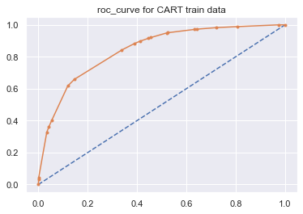

```
-------------------------------------------
roc_auc_score for test data for CART:  0.7995293458467572
```

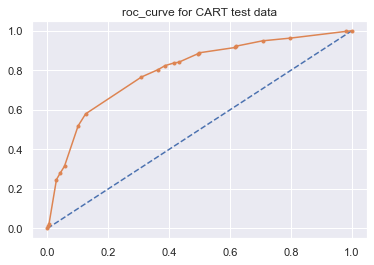

```python
ytrain_predict_proba = best_grid_dtcl.predict_proba(X_train)

ytrain_predict_proba = ytrain_predict_proba[:,1]

auc_dtcl_train = roc_auc_score(train_labels, ytrain_predict_proba)

print('roc_auc_score for train data for CART: ',auc_dtcl_train)

fpr_dtcl_train,tpr_dtcl_train,thresholds_dtcl_train = roc_curve(train_labels, ytrain_predict_proba)

plt.plot([0,1],[0,1],linestyle='--')

plt.plot(fpr_dtcl_train,tpr_dtcl_train,marker='.')
plt.title('roc_curve for CART train data')

plt.show()

print('-------------------------------------------')

ytest_predict_proba = best_grid_dtcl.predict_proba(X_test)

ytest_predict_proba = ytest_predict_proba[:,1]

auc_dtcl_test = roc_auc_score(test_labels, ytest_predict_proba)

print('roc_auc_score for test data for CART: ',auc_dtcl_test)


fpr_dtcl_test,tpr_dtcl_test,thresholds_dtcl_test = roc_curve(test_labels, ytest_predict_proba)

plt.plot([0,1],[0,1],linestyle='--')

plt.plot(fpr_dtcl_test,tpr_dtcl_test,marker='.')
plt.title('roc_curve for CART test data')

plt.show()
```

### ROC_AUC_SCORE and ROC_CURVE for RANDOM FOREST Classifier

[output not shown]

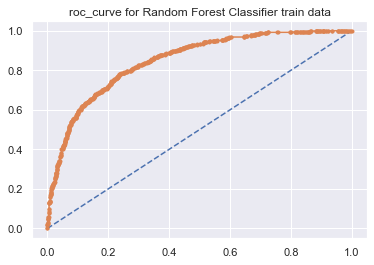

```
-------------------------------------------
roc_auc_score for test data for Random Forest Classifier:  0.8200112060512676
```

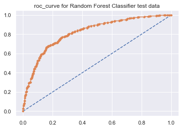

```python
ytrain_predict_prob = best_grid.predict_proba(X_train)

ytrain_predict_prob = ytrain_predict_prob[:,1]

auc_rfcl_train = roc_auc_score(train_labels, ytrain_predict_proba)

print('roc_auc_score for train data for Random Forest Classifier: ',auc_rfcl_train)

fpr_rfcl_train,tpr_rfcl_train,thresholds_rfcl_train = roc_curve(train_labels, ytrain_predict_prob)

plt.plot([0,1],[0,1],linestyle='--')

plt.plot(fpr_rfcl_train,tpr_rfcl_train,marker='.')
plt.title('roc_curve for Random Forest Classifier train data')

plt.show()

print('-------------------------------------------')

ytest_predict_prob = best_grid.predict_proba(X_test)

ytest_predict_prob = ytest_predict_prob[:,1]

auc_rfcl_test = roc_auc_score(test_labels, ytest_predict_prob)

print('roc_auc_score for test data for Random Forest Classifier: ',auc_rfcl_test)


fpr_rfcl_test,tpr_rfcl_test,thresholds_rfcl_test = roc_curve(test_labels, ytest_predict_prob)

plt.plot([0,1],[0,1],linestyle='--')

plt.plot(fpr_rfcl_test,tpr_rfcl_test,marker='.')
plt.title('roc_curve for Random Forest Classifier test data')

plt.show()
```

[output not shown]

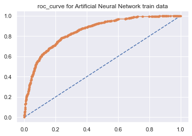

[output not shown]

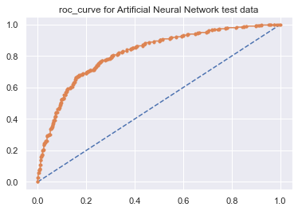

```python
ytrain_predict_prob_neural = best_grid.predict_proba(X_train)

ytrain_predict_prob_neural = ytrain_predict_prob_neural[:,1]

auc_neural_train = roc_auc_score(train_labels, ytrain_predict_prob_neural)

print('roc_auc_score for train data for Artificial Neural Network: ',auc_neural_train)

fpr_neural_train,tpr_neural_train,thresholds_neural_train = roc_curve(train_labels, ytrain_predict_prob_neural)

plt.plot([0,1],[0,1],linestyle='--')

plt.plot(fpr_neural_train,tpr_neural_train,marker='.')
plt.title('roc_curve for Artificial Neural Network train data')

plt.show()

print('-------------------------------------------')

ytest_predict_prob_neural = best_grid.predict_proba(X_test)

ytest_predict_prob_neural = ytest_predict_prob_neural[:,1]

auc_neural_test = roc_auc_score(test_labels, ytest_predict_prob_neural)

print('roc_auc_score for test data for Artificial Neural Network: ',auc_neural_test)


fpr_neural_test,tpr_neural_test,thresholds_neural_test = roc_curve(test_labels, ytest_predict_prob_neural)

plt.plot([0,1],[0,1],linestyle='--')

plt.plot(fpr_neural_test,tpr_neural_test,marker='.')
plt.title('roc_curve for Artificial Neural Network test data')

plt.show()
```

### Comparison of AUC, Accuracy, Precision, Recall and F1 Score between all 3 models:

As we can see from the above calculations and classification report, below are some values that we got:

```python
#AUC, Accuracy, Precision, Recall and F1 Score for CART

#train data
cart_train_acc=0.80
cart_train_recall=0.62
cart_train_precision=0.69
cart_train_f1=0.65

#test data
cart_test_acc=0.77
cart_test_recall=0.52
cart_test_precision=0.71
cart_test_f1=0.60

#AUC, Accuracy, Precision, Recall and F1 Score for RFCL


#train data
rf_train_acc=0.80
rf_train_recall=0.57
rf_train_precision=0.72
rf_train_f1=0.64

#test data
rf_test_acc=0.77
rf_test_recall=0.47
rf_test_precision=0.72
rf_test_f1=0.57

#AUC, Accuracy, Precision, Recall and F1 Score for ANN

#train data
neural_train_acc=0.77
neural_train_recall=0.41
neural_train_precision=0.68
neural_train_f1=0.52

#test data
neural_test_acc=0.75
neural_test_recall=0.34
neural_test_precision=0.74
neural_test_f1=0.47
```

### Table for Comparison of all values:

```python
index=['Accuracy', 'AUC', 'Recall','Precision','F1 Score']

data = pd.DataFrame({'CART_train':[cart_train_acc,auc_dtcl_train,cart_train_recall,cart_train_precision,cart_train_f1],
        'CART_test':[cart_test_acc,auc_dtcl_test,cart_test_recall,cart_test_precision,cart_test_f1],
       'Random_Forest_train':[rf_train_acc,auc_rfcl_train,rf_train_recall,rf_train_precision,rf_train_f1],
        'Random_Forest_test':[rf_test_acc,auc_rfcl_test,rf_test_recall,rf_test_precision,rf_test_f1],
       'Neural_Network_train':[neural_train_acc,auc_neural_train,neural_train_recall,neural_train_precision,neural_train_f1],
        'Neural_Network_test':[neural_test_acc,auc_neural_test,neural_test_recall,neural_test_precision,neural_test_f1]},index=index)
round(data,2)
```

|  | CART_train | CART_test | Random_Forest_train | Random_Forest_test | Neural_Network_train | Neural_Network_test |
| --- | --- | --- | --- | --- | --- | --- |
| Accuracy | 0.80 | 0.77 | 0.80 | 0.77 | 0.77 | 0.75 |
| AUC | 0.84 | 0.80 | 0.84 | 0.82 | 0.85 | 0.82 |
| Recall | 0.62 | 0.52 | 0.57 | 0.47 | 0.41 | 0.34 |
| Precision | 0.69 | 0.71 | 0.72 | 0.72 | 0.68 | 0.74 |
| F1 Score | 0.65 | 0.60 | 0.64 | 0.57 | 0.52 | 0.47 |

## 2.5 Inference: Based on the whole Analysis, what are the business insights and recommendations.

```
                         ------------------------------------"END"------------------------------------------------
```